# 多数算法教程

Xwyturbo

2022-10-22

# 0.数据的预处理

加载R包，读取李阁村数据，查看李阁村变量：code是用来确定院落影像空间对应关系的唯一指标；绿视率，即院落绿色植被所占的比重；太阳能有无，即院落内有太阳能热水器，值为1，反之，值为0；居住表示院落实际有无人居住：

```r
  library(tidyverse)
  library(readxl)
  library(readr)
  library(writexl)
  library(ggpubr)
  library(eoffice)
  lg <- read.csv("c:\\xwy_workplace\\R_projects\\lg.csv")
  str(lg)
```

```
## 'data.frame':    376 obs. of  5 variables:
##  $ X         : int  1 2 3 4 5 6 7 8 9 10 ...
##  $ code      : int  1 2 3 4 5 6 7 8 9 10 ...
##  $ 绿视率    : num  0.0823 0.0565 0.1707 0.0432 0.0786 ...
##  $ 太阳能有无: int  0 1 0 1 1 1 0 1 1 0 ...
##  $ 居住      : int  1 1 1 1 1 1 1 1 0 0 ...
```

```r
  #write_xlsx(lg,"c:\\xwy_workplace\\R_projects\\lg.xlsx")
  table(院落居住实际 = lg$居住,太阳能识别结果 = lg$太阳能有无)
```

```
##             太阳能识别结果
## 院落居住实际   0   1
##            0 108  13
##            1 106 149
```

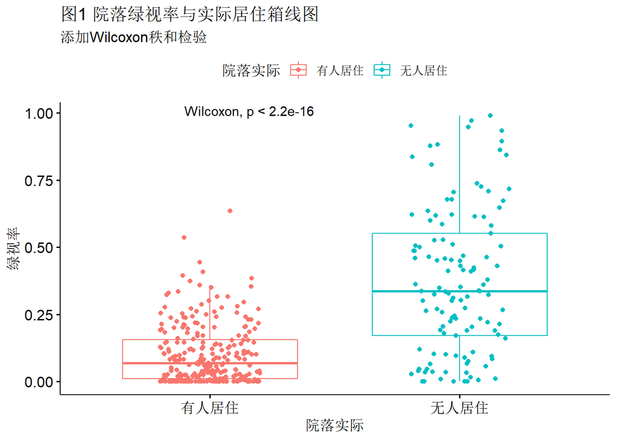

```r
  lg$院落实际 <- lg$居住
  lg$院落实际[lg$院落实际 == '0']<- '无人居住'
  lg$院落实际[lg$院落实际 == '1']<- '有人居住'

  fig1 <- ggboxplot(lg,x = "院落实际",y = "绿视率",
                    color = "院落实际",add = "jitter") +
    stat_compare_means() +
    labs(title = "图1 院落绿视率与实际居住箱线图",
         subtitle = "添加Wilcoxon秩和检验")
  fig1
```

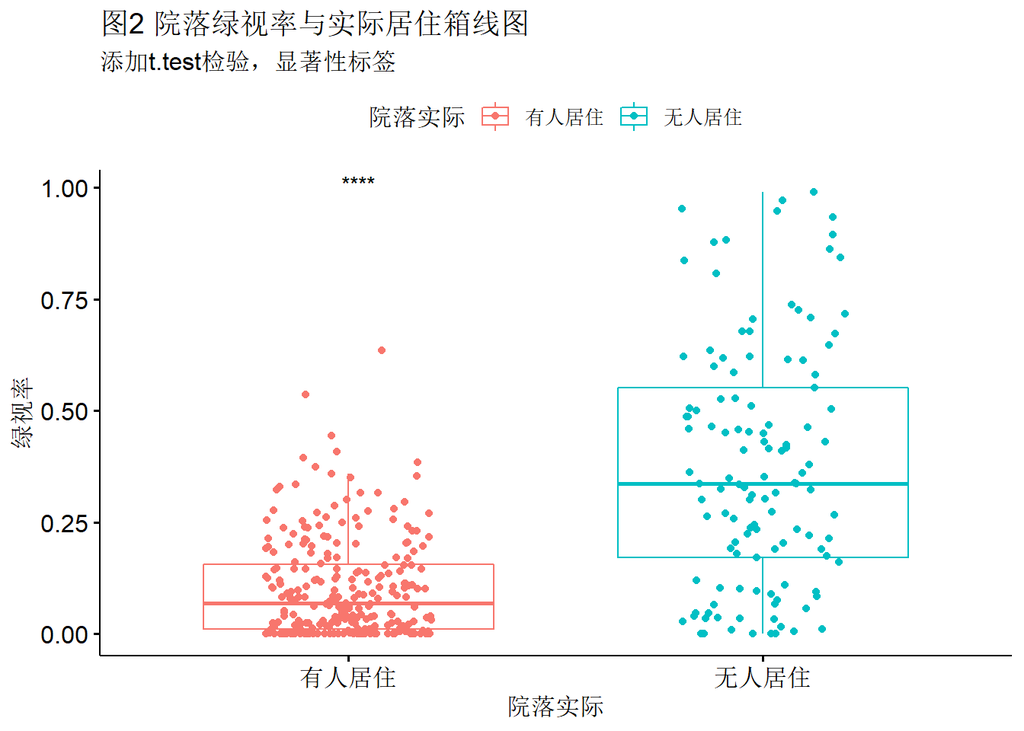

```r
  fig2 <- ggboxplot(lg,x = "院落实际",y = "绿视率",
                    color = "院落实际",add = "jitter") +
    stat_compare_means(method = "t.test",label = "p.signif")+
    labs(title = "图2 院落绿视率与实际居住箱线图",
         subtitle = "添加t.test检验，显著性标签")
  fig2
```

```r
  #topptx(fig2,"c:\\xwy_workplace\\R_projects\\院落绿视率与实际居住箱线图.pptx")
```

# 1.决策树算法

## 1.1 加载对应R包、李阁村原始数据，切分数据集，搭建决策树模型。

```r
  library(tidyverse)
  library(readxl)
  library(MASS)
```

```r
  library(rpart)
  library(rpart.plot)
  li_ge <- read_xlsx("c:\\xwy_workplace\\R_projects\\li_ge.xlsx")
  str(li_ge)
```

```
## tibble [376 × 4] (S3: tbl_df/tbl/data.frame)
##  $ code      : num [1:376] 1 2 3 4 5 6 7 8 9 10 ...
##  $ 绿视率    : num [1:376] 0.0823 0.0565 0.1707 0.0432 0.0786 ...
##  $ 太阳能有无: num [1:376] 0 1 0 1 1 1 0 1 1 0 ...
##  $ 居住      : num [1:376] 1 1 1 1 1 1 1 1 0 0 ...
```

```r
  #查看加载的数据。

  set.seed(4)
  s = sample(376,300)
  trainset = li_ge[s,2:4]
  testset = li_ge[-s,2:4]
  #数据集切分，300个训练，76阁测试。

  fl_tree_trainset <- trainset
  fl_tree_testset <- testset
  fl_tree_trainset$居住[fl_tree_trainset$居住 == '0']<- '无人居住'
  fl_tree_trainset$居住[fl_tree_trainset$居住 == '1']<- '有人居住'
  fl_tree_testset$居住[fl_tree_testset$居住 == '0']<- '无人居住'
  fl_tree_testset$居住[fl_tree_testset$居住 == '1']<- '有人居住'
  #转换为符合决策数模型的数据格式。

  tree_fit = rpart(居住~.,data = fl_tree_trainset)
  summary(tree_fit)
```

```
## Call:
## rpart(formula = 居住 ~ ., data = fl_tree_trainset)
##   n= 300
##
##           CP nsplit rel error    xerror       xstd
## 1 0.43689320      0 1.0000000 1.0000000 0.07984613
## 2 0.03883495      1 0.5631068 0.6116505 0.06849306
## 3 0.01000000      2 0.5242718 0.5922330 0.06768088
##
## Variable importance
##     绿视率 太阳能有无
##         87         13
##
## Node number 1: 300 observations,    complexity param=0.4368932
##   predicted class=有人居住  expected loss=0.3433333  P(node) =1
##     class counts:   103   197
##    probabilities: 0.343 0.657
##   left son=2 (75 obs) right son=3 (225 obs)
##   Primary splits:
##       绿视率     < 0.2979623 to the right, improve=41.70889, (0 missing)
##       太阳能有无 < 0.5       to the left,  improve=25.33444, (0 missing)
##
## Node number 2: 75 observations,    complexity param=0.03883495
##   predicted class=无人居住  expected loss=0.2  P(node) =0.25
##     class counts:    60    15
##    probabilities: 0.800 0.200
##   left son=4 (63 obs) right son=5 (12 obs)
##   Primary splits:
##       太阳能有无 < 0.5       to the left,  improve=6.222222, (0 missing)
##       绿视率     < 0.4099958 to the right, improve=4.668693, (0 missing)
##   Surrogate splits:
##       绿视率 < 0.3071158 to the right, agree=0.867, adj=0.167, (0 split)
##
## Node number 3: 225 observations
##   predicted class=有人居住  expected loss=0.1911111  P(node) =0.75
##     class counts:    43   182
##    probabilities: 0.191 0.809
##
## Node number 4: 63 observations
##   predicted class=无人居住  expected loss=0.1111111  P(node) =0.21
##     class counts:    56     7
##    probabilities: 0.889 0.111
##
## Node number 5: 12 observations
##   predicted class=有人居住  expected loss=0.3333333  P(node) =0.04
##     class counts:     4     8
##    probabilities: 0.333 0.667
```

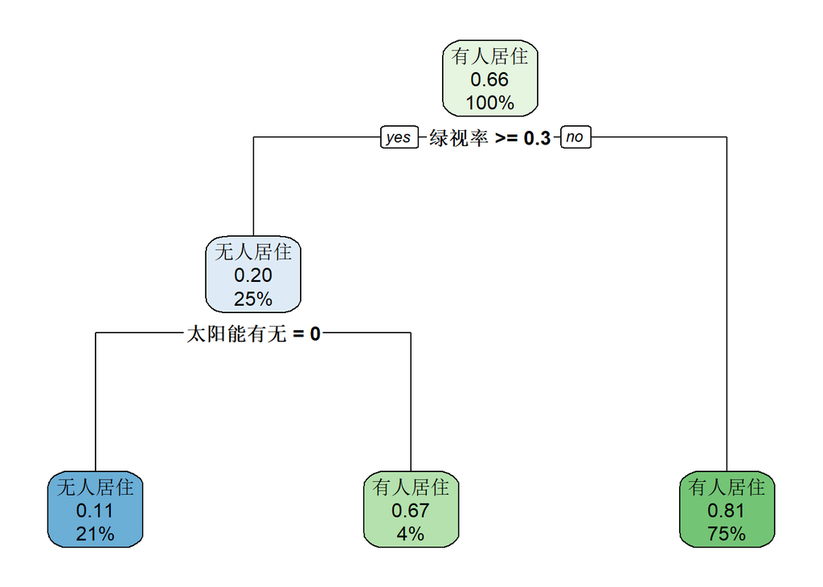

```r
  #更详细的决策树分裂规则。
  rpart.plot(tree_fit,type = 2)
```

```r
  #决策树模型可视化：
  #百分数表示抽样的样本占全体的量，
  #小数表示抽样样本中有人居住的比重。
```

## 1.2 决策树模型评价，包括对训练集：300个；测试集：76个的评价。

```r
  tree_pre_train = predict(tree_fit,fl_tree_trainset,type = "class")
  tree_t_train = table(tree_pre_train,fl_tree_trainset$居住)
  tree_t_train#查看生成的训练集混淆矩阵
```

```
##
## tree_pre_train 无人居住 有人居住
##       无人居住       56        7
##       有人居住       47      190
```

```r
  (tree_acc_train = sum(diag(tree_t_train))/nrow(trainset))
```

```
## [1] 0.82
```

```r
  #训练集准确率
  (tree_rec_train = tree_t_train[1,1]/(tree_t_train[1,1]+tree_t_train[1,2]))
```

```
## [1] 0.8888889
```

```r
  #训练集召回率
  (tree_sen_train = tree_t_train[1,1]/(tree_t_train[1,1]+tree_t_train[2,1]))
```

```
## [1] 0.5436893
```

```r
  #训练集灵敏度
  (tree_spe_train = tree_t_train[2,2]/(tree_t_train[1,2]+tree_t_train[2,2]))
```

```
## [1] 0.964467
```

```r
  #训练集特异度
  library(vcd)
  Kappa(tree_t_train)->a
  k1<-as.data.frame(a[[1]])
  k1<-k1[1,1]
  k1#训练集科恩卡帕系数
```

```
## [1] 0.5600456
```

```r
  tree_pre_test = predict(tree_fit,fl_tree_testset,type = "class")
  tree_t_test = table(tree_pre_test,fl_tree_testset$居住)
  tree_t_test#查看生成的测试集混淆矩阵
```

```
##
## tree_pre_test 无人居住 有人居住
##      无人居住        9        1
##      有人居住        9       57
```

```r
  (tree_acc_test = sum(diag(tree_t_test))/nrow(testset))
```

```
## [1] 0.8684211
```

```r
  #测试集准确率
  (tree_rec_test = tree_t_test[1,1]/(tree_t_test[1,1]+tree_t_test[1,2]))
```

```
## [1] 0.9
```

```r
  #测试集召回率
  (tree_sen_test = tree_t_test[1,1]/(tree_t_test[1,1]+tree_t_test[2,1]))
```

```
## [1] 0.5
```

```r
  #测试集灵敏度
  (tree_spe_test = tree_t_test[2,2]/(tree_t_test[1,2]+tree_t_test[2,2]))
```

```
## [1] 0.9827586
```

```r
  #测试集特异度
  library(vcd)
  Kappa(tree_t_test)->a2
  k11<-as.data.frame(a2[[1]])
  k11<-k11[1,1]
  k11#测试集科恩卡帕系数
```

```
## [1] 0.5701357
```

# 2.二元逻辑回归算法

## 2.1 加载对应R包、李阁村数据，保证数据集的切分与前者一致。

```r
  library(forestmodel)
  logistic_trainset<-trainset
  logistic_testset<-testset
  str(logistic_trainset)
```

```
## tibble [300 × 3] (S3: tbl_df/tbl/data.frame)
##  $ 绿视率    : num [1:300] 0 0 0.9899 0 0.0643 ...
##  $ 太阳能有无: num [1:300] 0 0 0 1 0 0 1 1 0 0 ...
##  $ 居住      : num [1:300] 1 1 0 1 1 1 0 1 1 0 ...
```

```r
  #查看加载的训练集数据。
  str(logistic_testset)
```

```
## tibble [76 × 3] (S3: tbl_df/tbl/data.frame)
##  $ 绿视率    : num [1:76] 0.1707 0.0014 0.1826 0.1084 0.0237 ...
##  $ 太阳能有无: num [1:76] 0 1 1 1 1 0 0 1 1 0 ...
##  $ 居住      : num [1:76] 1 1 1 1 1 0 0 1 1 0 ...
```

```r
  #查看加载的测试集数据。
  options(scipen = 200)
  #200以内的数，取消科学计数法。
  logistic_trainset$居住<-as.factor(logistic_trainset$居住)
  logistic_testset$居住<-as.factor(logistic_testset$居住)
  #转化为符合二元逻辑回归的数据格式。
  logistic_fit<-glm(居住~.,data = logistic_trainset,family = binomial)
  summary(logistic_fit)
```

```
##
## Call:
## glm(formula = 居住 ~ ., family = binomial, data = logistic_trainset)
##
## Deviance Residuals:
##     Min       1Q   Median       3Q      Max
## -2.5457  -0.4383   0.3090   0.6980   2.0594
##
## Coefficients:
##             Estimate Std. Error z value        Pr(>|z|)
## (Intercept)   1.4008     0.2559   5.474 0.0000000440895 ***
## 绿视率       -6.3199     0.9594  -6.587 0.0000000000448 ***
## 太阳能有无    1.7995     0.3779   4.762 0.0000019145728 ***
## ---
## Signif. codes:  0 '***' 0.001 '**' 0.01 '*' 0.05 '.' 0.1 ' ' 1
##
## (Dispersion parameter for binomial family taken to be 1)
##
##     Null deviance: 385.93  on 299  degrees of freedom
## Residual deviance: 252.12  on 297  degrees of freedom
## AIC: 258.12
##
## Number of Fisher Scoring iterations: 5
```

```r
  ##查看logistic_fit，发现变量均通过假设检验对应方程。
  forest_model(logistic_fit)
```

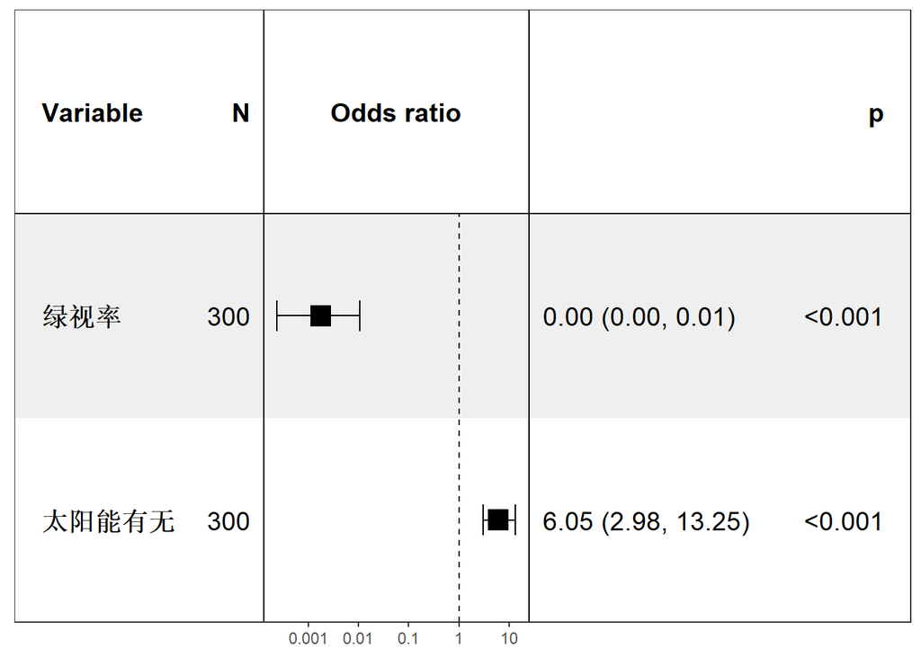

```r
  #基于回归模型的结果绘制森林图。
```

所得回归方程中的常数项为1.4，绿视率x1的系数为-6.3，太阳能有无x2为1.8完整的回归方程为：
$$Y = exp(1.4-6.3x1+1.8x2)/(1+exp(1.4
-6.3x1+1.8x2))$$

## 2.2 二元逻辑回归模型评价，包括对训练集：300个；测试集：76个的评价。

```r
  logistic_prob_train<-predict(logistic_fit,logistic_trainset,type = "response")
  logistic_pred_train<-logistic_prob_train>0.5
  logistic_table_train<-table(Predicted=logistic_pred_train,Actual=logistic_trainset$居住)
  logistic_table_train#查看生成的训练集混淆矩阵
```

```
##          Actual
## Predicted   0   1
##     FALSE  65  17
##     TRUE   38 180
```

```r
  (log_acc_train = sum(diag(logistic_table_train))/nrow(trainset))
```

```
## [1] 0.8166667
```

```r
  #训练集准确率
  (log_rec_train = logistic_table_train[1,1]/(logistic_table_train[1,1]+logistic_table_train[1,2]))
```

```
## [1] 0.7926829
```

```r
  #训练集召回率
  (log_sen_train = logistic_table_train[1,1]/(logistic_table_train[1,1]+logistic_table_train[2,1]))
```

```
## [1] 0.631068
```

```r
  #训练集灵敏度
  (log_spe_train = logistic_table_train[2,2]/(logistic_table_train[1,2]+logistic_table_train[2,2]))
```

```
## [1] 0.9137056
```

```r
  #训练集特异度
  library(vcd)
  Kappa(logistic_table_train)->b
  k2<-as.data.frame(b[[1]])
  k2<-k2[1,1]
  k2#训练集科恩卡帕系数
```

```
## [1] 0.5726274
```

```r
  logistic_prob_test<-predict(logistic_fit,type = "response",newdata = logistic_testset)
  logistic_pred_test<-logistic_prob_test>0.5
  logistic_table_test<-table(Predicted=logistic_pred_test,Actual=logistic_testset$居住)#查看生成的测试集混淆矩阵

  (log_acc_test = sum(diag(logistic_table_test))/nrow(testset))
```

```
## [1] 0.8421053
```

```r
  #测试集准确率
  (log_rec_test = logistic_table_test[1,1]/(logistic_table_test[1,1]+logistic_table_test[1,2]))
```

```
## [1] 0.75
```

```r
  #测试集召回率
  (log_sen_test = logistic_table_test[1,1]/(logistic_table_test[1,1]+logistic_table_test[2,1]))
```

```
## [1] 0.5
```

```r
  #测试集灵敏度
  (log_spe_test = logistic_table_test[2,2]/(logistic_table_test[1,2]+logistic_table_test[2,2]))
```

```
## [1] 0.9482759
```

```r
  #测试集特异度
  library(vcd)
  Kappa(tree_t_test)->b2
  k22<-as.data.frame(b2[[1]])
  k22<-k22[1,1]
  k22#测试集科恩卡帕系数
```

```
## [1] 0.5701357
```

# 3.随机森林算法

## 3.1 加载对应R包、李阁村数据，保证数据集的切分与前者一致。

```r
  library(forestmodel)
  library(randomForest)
  rf_trainset<-trainset
  rf_testset<-testset
  str(rf_trainset)
```

```
## tibble [300 × 3] (S3: tbl_df/tbl/data.frame)
##  $ 绿视率    : num [1:300] 0 0 0.9899 0 0.0643 ...
##  $ 太阳能有无: num [1:300] 0 0 0 1 0 0 1 1 0 0 ...
##  $ 居住      : num [1:300] 1 1 0 1 1 1 0 1 1 0 ...
```

```r
  #查看加载的训练集数据。
  str(rf_testset)
```

```
## tibble [76 × 3] (S3: tbl_df/tbl/data.frame)
##  $ 绿视率    : num [1:76] 0.1707 0.0014 0.1826 0.1084 0.0237 ...
##  $ 太阳能有无: num [1:76] 0 1 1 1 1 0 0 1 1 0 ...
##  $ 居住      : num [1:76] 1 1 1 1 1 0 0 1 1 0 ...
```

```r
  #查看加载的测试集数据。
  options(scipen = 200)
  #200以内的数，取消科学计数法。
  rf_trainset$居住<-as.factor(rf_trainset$居住)
  rf_testset$居住<-as.factor(rf_testset$居住)
  rf_fit <- randomForest(formula = 居住~.,data =rf_trainset,mtry=1,
                         importance = TRUE,ntree=15000)
  rf_fit
```

```
##
## Call:
##  randomForest(formula = 居住 ~ ., data = rf_trainset, mtry = 1,      importance = TRUE, ntree = 15000)
##                Type of random forest: classification
##                      Number of trees: 15000
## No. of variables tried at each split: 1
##
##         OOB estimate of  error rate: 20%
## Confusion matrix:
##    0   1 class.error
## 0 55  48  0.46601942
## 1 12 185  0.06091371
```

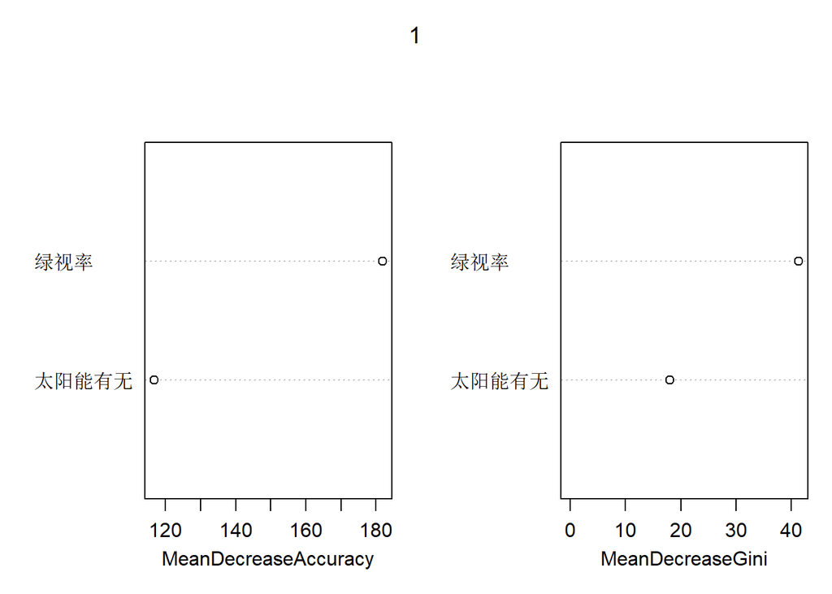

```r
  varImpPlot(rf_fit,main = 01)
```

```r
  #partialPlot(rf_fit,rf_trainset,x.var = 绿视率)
```

## 3.2 随机森林模型评价，包括对包括对训练集：300个；测试集：76个的评价。

```r
  rf_trained <- predict(rf_fit,newdata = rf_trainset)
  rf_table_train <- table(Predicted=rf_trained, Actual=rf_trainset$居住)
  rf_table_train#查看生成的训练集混淆矩阵
```

```
##          Actual
## Predicted   0   1
##         0  60   9
##         1  43 188
```

```r
  (rf_acc_train = sum(diag(rf_table_train))/nrow(rf_trainset))
```

```
## [1] 0.8266667
```

```r
  #训练集准确率
  (rf_rec_train = rf_table_train[1,1]/(rf_table_train[1,1]+rf_table_train[1,2]))
```

```
## [1] 0.8695652
```

```r
  #训练集召回率
  (rf_sen_train = rf_table_train[1,1]/(rf_table_train[1,1]+rf_table_train[2,1]))
```

```
## [1] 0.5825243
```

```r
  #训练集灵敏度
  (rf_spe_train = rf_table_train[2,2]/(rf_table_train[1,2]+rf_table_train[2,2]))
```

```
## [1] 0.9543147
```

```r
  #训练集特异度
  library(vcd)
  Kappa(rf_table_train)->c
  k3<-as.data.frame(c[[1]])
  k3<-k3[1,1]
  k3#训练集科恩卡帕系数
```

```
## [1] 0.5827315
```

```r
  rf_pred <- predict(rf_fit,newdata = rf_testset)
  rf_table_test <- table(rf_pred,rf_testset$居住)#查看生成的测试集混淆矩阵

  (rf_acc_test = sum(diag(rf_table_test ))/nrow(rf_testset))
```

```
## [1] 0.8552632
```

```r
  #测试集准确率
  (rf_rec_test = rf_table_test[1,1]/(rf_table_test[1,1]+rf_table_test[1,2]))
```

```
## [1] 0.8181818
```

```r
  #测试集召回率
  (rf_sen_test = rf_table_test[1,1]/(rf_table_test[1,1]+rf_table_test[2,1]))
```

```
## [1] 0.5
```

```r
  #测试集灵敏度
  (rf_spe_test = rf_table_test[2,2]/(rf_table_test[1,2]+rf_table_test[2,2]))
```

```
## [1] 0.9655172
```

```r
  #测试集特异度
  library(vcd)
  Kappa(rf_table_test)->c2
  k33<-as.data.frame(c2[[1]])
  k33<-k33[1,1]
  k33#测试集科恩卡帕系数
```

```
## [1] 0.5376106
```

# 4.支持向量机算法

## 4.1 加载对应R包、李阁村数据，保证数据集的切分与前者一致。

```r
  library(tidyverse)
  library(MASS)
  library(margins)
  library(e1071)
  svm_trainset<-trainset
  #查看加载的训练集数据。
  svm_testset<-testset
  #查看加载的测试集数据。
  options(scipen = 200)
  #200以内的数，取消科学计数法
  svm_trainset$居住<-as.factor(svm_trainset$居住)
  svm_testset$居住<-as.factor(svm_testset$居住)
  svm_fit<-svm(居住~.,data = svm_trainset,kernel="linear",cost=1)
  summary(svm_fit)
```

```
##
## Call:
## svm(formula = 居住 ~ ., data = svm_trainset, kernel = "linear",
##     cost = 1)
##
##
## Parameters:
##    SVM-Type:  C-classification
##  SVM-Kernel:  linear
##        cost:  1
##
## Number of Support Vectors:  138
##
##  ( 69 69 )
##
##
## Number of Classes:  2
##
## Levels:
##  0 1
```

## 4.2 支持向量机模型评价，包括对包括对训练集：300个；测试集：76个的评价。

```r
  svm_pred_train<-predict(svm_fit,svm_trainset)
  svm_table_train<-table(Predicted=svm_pred_train,Actual=svm_trainset$居住)
  svm_table_train#查看生成的训练集混淆矩阵
```

```
##          Actual
## Predicted   0   1
##         0  58  11
##         1  45 186
```

```r
  (svm_acc_train = sum(diag(rf_table_train))/nrow(rf_trainset))
```

```
## [1] 0.8266667
```

```r
  #训练集准确率
  (svm_rec_train = rf_table_train[1,1]/(rf_table_train[1,1]+rf_table_train[1,2]))
```

```
## [1] 0.8695652
```

```r
  #训练集召回率
  (svm_sen_train = rf_table_train[1,1]/(rf_table_train[1,1]+rf_table_train[2,1]))
```

```
## [1] 0.5825243
```

```r
  #训练集灵敏度
  (svm_spe_train = rf_table_train[2,2]/(rf_table_train[1,2]+rf_table_train[2,2]))
```

```
## [1] 0.9543147
```

```r
  #训练集特异度
  library(vcd)
  Kappa(svm_table_train)->d
  k4<-as.data.frame(d[[1]])
  k4<-k4[1,1]
  k4#训练集科恩卡帕系数
```

```
## [1] 0.5506339
```

```r
  svm_pred <- predict(svm_fit,newdata = svm_testset)
  svm_table_test <- table(svm_pred,svm_testset$居住)#查看生成的测试集混淆矩阵

  (svm_acc_test = sum(diag(svm_table_test))/nrow(svm_testset))
```

```
## [1] 0.8552632
```

```r
  #测试集准确率
  (svm_rec_test = svm_table_test[1,1]/(svm_table_test[1,1]+svm_table_test[1,2]))
```

```
## [1] 0.8181818
```

```r
  #测试集召回率
  (svm_sen_test = svm_table_test[1,1]/(svm_table_test[1,1]+svm_table_test[2,1]))
```

```
## [1] 0.5
```

```r
  #测试集灵敏度
  (svm_spe_test = svm_table_test[2,2]/(svm_table_test[1,2]+svm_table_test[2,2]))
```

```
## [1] 0.9655172
```

```r
  #测试集特异度
  library(vcd)
  Kappa(svm_table_test)->d2
  k44<-as.data.frame(d2[[1]])
  k44<-k44[1,1]
  k44#测试集科恩卡帕系数
```

```
## [1] 0.5376106
```

# 5.神经网络算法

## 5.1 加载对应R包、李阁村数据，保证数据集的切分与前者一致。

```r
  library(tidyverse)
  library(MASS)
  library(margins)
  library(e1071)
  library(neuralnet)
  neural_trainset<-trainset
  neural_testset<-testset
  neural_trainset$居住<-as.factor(neural_trainset$居住)
  neural_testset$居住<-as.factor(neural_testset$居住)
  neural_fit<-neuralnet(居住~.,data = neural_trainset,hidden=10,linear.output=FALSE)
  summary(neural_fit)
```

```
##                     Length Class      Mode
## call                  5    -none-     call
## response            600    -none-     logical
## covariate           600    -none-     numeric
## model.list            2    -none-     list
## err.fct               1    -none-     function
## act.fct               1    -none-     function
## linear.output         1    -none-     logical
## data                  3    data.frame list
## exclude               0    -none-     NULL
## net.result            1    -none-     list
## weights               1    -none-     list
## generalized.weights   1    -none-     list
## startweights          1    -none-     list
## result.matrix        55    -none-     numeric
```

## 5.2 神经网络模型评价，包括对包括对训练集：300个；测试集：76个的评价。

```r
  neural_prob_train<-predict(neural_fit,neural_trainset)
  neural_pred_train<-neural_prob_train>0.5
  neural_table_train<-table(Predicted=neural_pred_train[,2],Actual=neural_trainset$居住)
  neural_table_train#查看生成的训练集混淆矩阵
```

```
##          Actual
## Predicted   0   1
##     FALSE  61  14
##     TRUE   42 183
```

```r
  (neural_acc_train = sum(diag(neural_table_train))/nrow(neural_trainset))
```

```
## [1] 0.8133333
```

```r
  #训练集准确率
  (neural_rec_train = neural_table_train[1,1]/(neural_table_train[1,1]+neural_table_train[1,2]))
```

```
## [1] 0.8133333
```

```r
  #训练集召回率
  (neural_sen_train = neural_table_train[1,1]/(neural_table_train[1,1]+neural_table_train[2,1]))
```

```
## [1] 0.592233
```

```r
  #训练集灵敏度
  (neural_spe_train = neural_table_train[2,2]/(neural_table_train[1,2]+neural_table_train[2,2]))
```

```
## [1] 0.928934
```

```r
  #训练集特异度
  library(vcd)
  Kappa(neural_table_train)->e
  k5<-as.data.frame(e[[1]])
  k5<-k5[1,1]
  k5#训练集科恩卡帕系数
```

```
## [1] 0.5573123
```

```r
  neural_prob_test<-predict(neural_fit,newdata = neural_testset)
  neural_pred_test<-neural_prob_test>0.5
  neural_table_test<-table(Predicted=neural_pred_test[,2],Actual=neural_testset$居住)
  neural_table_test#查看生成的测试集混淆矩阵
```

```
##          Actual
## Predicted  0  1
##     FALSE  9  2
##     TRUE   9 56
```

```r
  (neural_acc_test = sum(diag(neural_table_train))/nrow(neural_trainset))
```

```
## [1] 0.8133333
```

```r
  #测试集集准确率
  (neural_rec_test = neural_table_test[1,1]/(neural_table_test[1,1]+neural_table_test[1,2]))
```

```
## [1] 0.8181818
```

```r
  #测试集召回率
  (neural_sen_test = neural_table_test[1,1]/(neural_table_test[1,1]+neural_table_test[2,1]))
```

```
## [1] 0.5
```

```r
  #测试集灵敏度
  (neural_spe_test = neural_table_test[2,2]/(neural_table_test[1,2]+neural_table_test[2,2]))
```

```
## [1] 0.9655172
```

```r
  #测试集特异度
  library(vcd)
  Kappa(neural_table_test)->e2
  k55<-as.data.frame(e2[[1]])
  k55<-k55[1,1]
  k55#测试集科恩卡帕系数
```

```
## [1] 0.5376106
```

# 6.References:略。